# Splitgate Report

Ryan Poertner

11/23/2021

# Research Question

## Understanding the phenomenon

**background:** Video game

**goal:** To determine what in-game behaviors influence the odds of winning a match in Splitgate.

# Dataset

## Response

**Win:** Whether or not the subject won the match. This is binary in nature.

## Explanatory

**Kills:** how many kills the subject had in a match

**Deaths:** how many times the subject died in a match

**Assists:** how many times the subject contributed to killing an opponent without landing the killing shot in a match.

**Headshots Landed:** how many headshots the subject landed on the opposing side.

**Kills Per Minute:** how many kills the subject had per minute.

**Distance Portaled:** cumulative distance traveled by subject(in Meters).

**Portals Spawned:** how many portals the subject created.

**Damage Dealt:** how much damage the subject dealt(in points).

# Exploration of Data

The majority of the data appeared either linear or ambiguous in distribution, so I did not perform any transformations. however, I did notice a handful of outliers in headshots landed and distance portaled, so I subsetted the data based on that.

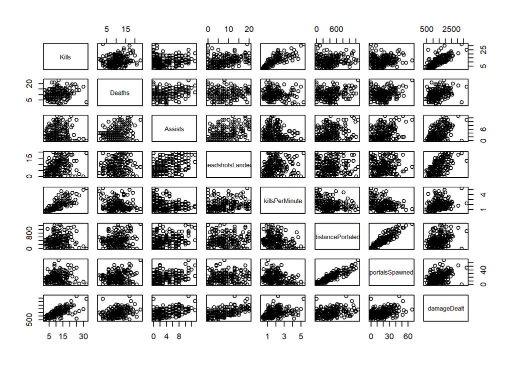

Table of 5 number summary

|  | Win | Kills | Assists | Deaths | headshotsLanded | killsPerMinute | distancePortaled | portalsSpawned | damageDealt |
| --- | --- | --- | --- | --- | --- | --- | --- | --- | --- |
|  | Min. :0.0000 | Min. : 2.0 | Min. : 0.00 | Min. : 1.00 | Min. : 0.000 | Min. :0.400 | Min. : 0.0 | Min. : 0.00 | Min. : 376 |
|  | 1st Qu.:0.0000 | 1st Qu.: 7.0 | 1st Qu.: 1.00 | 1st Qu.: 7.75 | 1st Qu.: 4.000 | 1st Qu.:1.215 | 1st Qu.: 216.2 | 1st Qu.:10.00 | 1st Qu.:1032 |
|  | Median :1.0000 | Median :11.0 | Median : 3.00 | Median :10.00 | Median : 7.000 | Median :1.670 | Median : 399.0 | Median :18.00 | Median :1374 |
|  | Mean :0.5102 | Mean :11.4 | Mean : 3.99 | Mean :10.48 | Mean : 8.092 | Mean :1.936 | Mean : 419.6 | Mean :19.56 | Mean :1438 |
|  | 3rd Qu.:1.0000 | 3rd Qu.:14.0 | 3rd Qu.: 7.00 | 3rd Qu.:13.00 | 3rd Qu.:12.000 | 3rd Qu.:2.430 | 3rd Qu.: 587.5 | 3rd Qu.:28.00 | 3rd Qu.:1796 |
|  | Max. :1.0000 | Max. :32.0 | Max. :13.00 | Max. :23.00 | Max. :20.000 | Max. :5.330 | Max. :1264.0 | Max. :67.00 | Max. :3753 |

## SLLR Model

Table of Estimates and Std. Errors

|  | Estimate | Std. Error | z value | Pr(>\|z\|) |
| --- | --- | --- | --- | --- |
| Kills | 0.2544265 | 0.1214715 | 2.0945362 | 0.0362122 |
| Deaths | -0.2887410 | 0.0758534 | -3.8065651 | 0.0001409 |
| Assists | 0.3152713 | 0.1048869 | 3.0058213 | 0.0026486 |
| headshotsLanded | 0.0530889 | 0.0502101 | 1.0573352 | 0.2903586 |
| killsPerMinute | -0.1232618 | 0.5032587 | -0.2449273 | 0.8065128 |
| distancePortaled | 0.0016760 | 0.0018148 | 0.9235105 | 0.3557412 |
| portalsSpawned | -0.0613908 | 0.0415564 | -1.4772894 | 0.1395981 |
| damageDealt | -0.0013018 | 0.0010462 | -1.2442892 | 0.2133931 |

Table of probability coefficients

|  | x |
| --- | --- |
| Kills | 1.2897217 |
| Deaths | 0.7492062 |
| Assists | 1.3706310 |
| headshotsLanded | 1.0545234 |
| killsPerMinute | 0.8840322 |
| distancePortaled | 1.0016774 |
| portalsSpawned | 0.9404556 |
| damageDealt | 0.9986991 |

Table of confidence intervals

|  | 2.5 % | 97.5 % |
| --- | --- | --- |
| Kills | 1.0223660 | 1.6535534 |
| Deaths | 0.6385202 | 0.8612596 |
| Assists | 1.1265289 | 1.7042239 |
| headshotsLanded | 0.9561470 | 1.1661034 |
| killsPerMinute | 0.3309818 | 2.4196179 |
| distancePortaled | 0.9982216 | 1.0054104 |
| portalsSpawned | 0.8640825 | 1.0186749 |
| damageDealt | 0.9966220 | 1.0007583 |

# Analysis

## Hypothesis Testing

### Kills

**Ho:** There is no statistically significant Kills effect on odds of winning.

**Ha:** There is a statistically significant Kills effect on odds of winning.

**z value:** 2.095

**p-value:** .0362

**Formal Conclusion:** We reject Ho in favor of Ha: There is a statistically significant Kills effect on odds of winning at the .05 confidence level.

**Informal Conclusion:** There is a statistically significant Kills effect on odds of winning(p-value = .0362).

**Effect:** Holding all else constant, for a one unit increase in Kills we estimate an expected 28.9% increase in odds of winning(95% CI: 2.2, 65.3).

### Deaths

**Ho:**There is no statistically significant Deaths effect on odds of winning.

**Ha:**There is a statistically significant Deaths effect on odds of winning.

**z value:** -3.807

**p-value:** .000141

**Formal:** We reject Ho in favor of Ha: There is a statistically significant Deaths effect on odds of winning at the .05 confidence level.

**Informal:** There is a statistically significant Deaths effect on odds of winning(p-value = .000141).

**Effect:** holding all else constant, for a 1 unit increase in Deaths, we estimate an expected 25.1% decrease in odds of winning(95% CI: 13.9, 36.2).

### Assists

**Ho:**There is no statistically significant Assists effect on odds of winning.

**Ha:**There is a statistically significant Assists effect on odds of winning.

**z-value:** 3.006 **p-value:** .002649 **Formal:** We reject Ho in favor of Ha: There is a statistically significant Assists effect on odds of winning at the .05 significance level

**Informal:** There is a statistically significant Assists effect on odds of winning(p-value = .0026).

### Headshots Landed

**Ho:**There is no statistically significant headshotsLanded effect on odds of winning.

**Ha:**There is a statistically significant headshotsLanded effect on odds of winning.

**z value:** 1.057

**p-value:** .290

**Formal Conclusion:** We fail to reject Ho: There is no statistically significant headshotsLanded effect on odds of winning at the .05 significance level.

**Informal Conclusion:** There is no statistically significant headshotsLanded effect on odds of winning(p-value = .290).

**Effect:** Holding all else constant, for a 1 unit increase in headshotsLanded, we estimate an expected increase in odds of winning by 5.5%(95% CI: -4.4, 16.6). However, there is not enough evidence to support a headshotsLanded effect.

### Kills Per Minute

**Ho:**There is no statistically significant killsPerMinute effect on odds of winning.

**Ha:**There is a statistically significant killsPerMinute effect on odds of winning.

**z value:** -0.245

**p-value:** .807

**Formal Conclusion:** We fail to reject Ho:There is no statistically significant killsPerMinute effect on odds of winning at the .05 significance level.

**Informal Conclusion:** There is no statistically significant killsPerMinute effect on odds of winning(p-value = .807)

**Effect:** Holding all else constant, for a 1 unit increase in killsPerMinute, we estimate an expected decrease in odds of winning by 11.6%(95% CI: -66.9, 141.96). However, there is not enough evidence to support a killsPerMinute effect.

### Distance Portaled

**Ho:**There is no statistically significant distancePortaled effect on odds of winning

**Ha:**There is a statistically significant distancePortaled effect on odds of winning

**z value:** .924

**p-value:** .356

**Formal Conclusion:** We fail to reject Ho:There is no statistically significant distancePortaled effect on odds of winning at the .05 significance level

**Informal Conclusion:** There is no statistically significant distancePortaled effect on odds of winning(p-value = .356)